# ДЗ Сентимент-анализ предложений с помощью линейных моделей

Теперь сравним SGD и GDC c оптимальными, по прошлым графикам, параметрами.

```python
w_0 = np.zeros(X.shape[1])
sgd = SGDClassifier('binary_logistic',
                    batch_size=10000,
                    step_alpha=0.1,
                    step_beta=0,
                    l2_coef=1e-6)
historysgd = sgd.fit(X,
                  y,
                  w_0,
                  True,
                  X_test=X_test,
                  y_test=y_test)

gdc = GDClassifier('binary_logistic',
                    step_alpha=0.1,
                    step_beta=0,
                    l2_coef=1e-6)
historygdc = gdc.fit(X,
                  y,
                  w_0,
                  True,
                  X_test=X_test,
                  y_test=y_test)
```

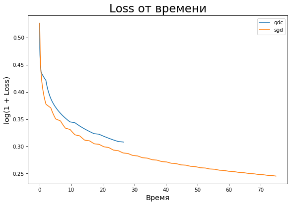

```python
plt.figure(figsize=(9,6), dpi=75)
plt.plot(np.cumsum(historygdc['time']), np.log1p(historygdc['func']), label='gdc')
plt.plot(np.cumsum(historysgd['time']), np.log1p(historysgd['func']), label='sgd')
plt.xlabel('Время', fontsize=14)
plt.ylabel('log(1 + Loss)', fontsize=14)
plt.title('Loss от времени', fontsize=22)
plt.legend()
plt.show()
```

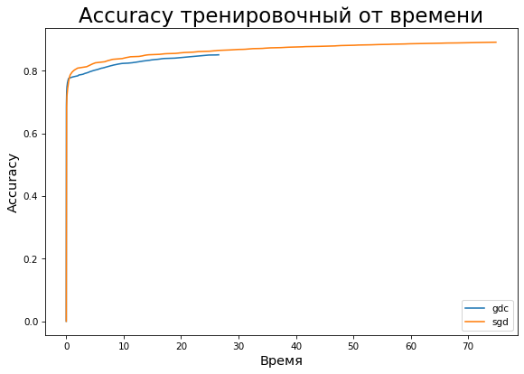

```python
plt.figure(figsize=(9,6), dpi=75)
plt.plot(np.cumsum(historygdc['time']), historygdc['train_acc'], label='gdc')
plt.plot(np.cumsum(historysgd['time']), historysgd['train_acc'], label='sgd')
plt.xlabel('Время', fontsize=14)
plt.ylabel('Accuracy', fontsize=14)
plt.title('Accuracy тренировочный от времени', fontsize=22)
plt.legend()
plt.show()
```

В целом за одно и то же время SGD работает лучше, при этом критерий останова у него срабатывает позже.

Теперь посмотрим на качество в зависимости от min_df.

```python
df_train = pd.read_csv('toxic_train.csv')
y = np.array(df_train['is_toxic'], dtype=int)
y = 2 * y - 1
corpus_train = list(df_train['comment_text'].map(preprocessing))
df_test = pd.read_csv('toxic_test.csv')
y_test = np.array(df_test['is_toxic'], dtype=int)
y_test = y_test * 2 - 1
corpus_test = list(df_test['comment_text'].map(preprocessing))
```

```python
K = [1, 2, 3, 10, 20]
```

```python
to_drow = {}
for k in K:
    vectorizer = CountVectorizer(min_df=k)
    X = vectorizer.fit_transform(corpus_train)
    X_test = vectorizer.transform(corpus_test)
    X = sp.sparse.hstack((X, np.ones(X.shape[0])[:, None]))
    X_test = sp.sparse.hstack((X_test, np.ones(X_test.shape[0])[:, None]))
    X = X.tocsr()
    X_test = X_test.tocsr()
    w_0 = np.zeros(X.shape[1])
    sgd = SGDClassifier('binary_logistic',
                    batch_size=10000,
                    step_alpha=0.1,
                    step_beta=0,
                    l2_coef=1e-6)
    history = sgd.fit(X,
                  y,
                  w_0,
                  True,
                  X_test=X_test,
                  y_test=y_test)
    to_drow[f'{k}'] = history
```

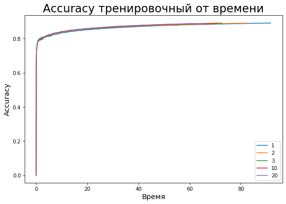

```python
plt.figure(figsize=(9,6), dpi=75)
for k in K:
    plt.plot(np.cumsum(to_drow[f'{k}']['time']), to_drow[f'{k}']['train_acc'], label=f'{k}')
plt.xlabel('Время', fontsize=14)
plt.ylabel('Accuracy', fontsize=14)
plt.title('Accuracy тренировочный от времени', fontsize=22)
plt.legend()
plt.show()
```

```python
print('Accuracy min_df=20:', max(to_drow['20']['train_acc']))
print('Accuracy min_df=1:', max(to_drow['1']['train_acc']))
```

```
Accuracy min_df=20: 0.8897639307735157
Accuracy min_df=1: 0.8916847544226965
```

Разница в точности при разных min_df практически незаметна, хоть и больше при уменьшении min_df, при этом требуется куда больше времени на обучение, так как увеличивается признаковое пространство.

Зависимость качества от max_df.

```python
K = [100, 1000, 2000, 3000, 5000]
```

```python
to_drow = {}
for k in K:
    vectorizer = CountVectorizer(min_df=9,max_df=k)
    X = vectorizer.fit_transform(corpus_train)
    X_test = vectorizer.transform(corpus_test)
    X = sp.sparse.hstack((X, np.ones(X.shape[0])[:, None]))
    X_test = sp.sparse.hstack((X_test, np.ones(X_test.shape[0])[:, None]))
    X = X.tocsr()
    X_test = X_test.tocsr()
    w_0 = np.zeros(X.shape[1])
    sgd = SGDClassifier('binary_logistic',
                    batch_size=10000,
                    step_alpha=0.1,
                    step_beta=0,
                    l2_coef=1e-6)
    history = sgd.fit(X,
                  y,
                  w_0,
                  True,
                  X_test=X_test,
                  y_test=y_test)
    to_drow[f'{k}'] = history
```

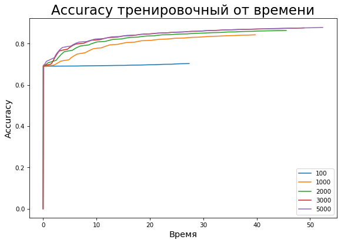

```python
plt.figure(figsize=(9,6), dpi=75)
for k in K:
    plt.plot(np.cumsum(to_drow[f'{k}']['time']), to_drow[f'{k}']['train_acc'], label=f'{k}')
plt.xlabel('Время', fontsize=14)
plt.ylabel('Accuracy', fontsize=14)
plt.title('Accuracy тренировочный от времени', fontsize=22)
plt.legend()
plt.show()
```

```python
print('Accuracy max_df=5000:', max(to_drow['5000']['train_acc']))
print('Accuracy max_df=100:', max(to_drow['100']['train_acc']))
```

```
Accuracy max_df=5000: 0.8782581971149229
Accuracy max_df=100: 0.7031367050191122
```

Как и с min_df ограничение учкоряет работу но плохо сказывается на точности.

Теперь попробуем tf-idf

```python
from sklearn.feature_extraction.text import TfidfVectorizer
```

```python
to_drow = {}
K = [1, 2, 3, 10, 20]
for k in K:
    vectorizer = TfidfVectorizer(min_df=k)
    X = vectorizer.fit_transform(corpus_train)
    X_test = vectorizer.transform(corpus_test)
    X = sp.sparse.hstack((X, np.ones(X.shape[0])[:, None]))
    X_test = sp.sparse.hstack((X_test, np.ones(X_test.shape[0])[:, None]))
    X = X.tocsr()
    X_test = X_test.tocsr()
    w_0 = np.zeros(X.shape[1])
    sgd = SGDClassifier('binary_logistic',
                    batch_size=10000,
                    step_alpha=0.1,
                    step_beta=0,
                    l2_coef=1e-6)
    history = sgd.fit(X,
                  y,
                  w_0,
                  True,
                  X_test=X_test,
                  y_test=y_test)
    to_drow[f'{k}'] = history
```

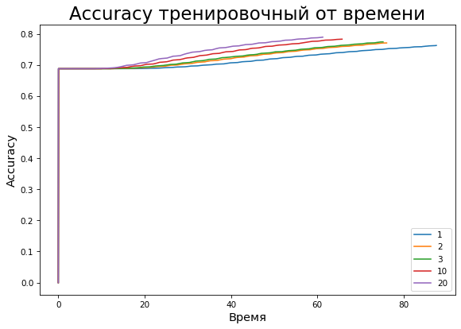

```python
plt.figure(figsize=(9,6), dpi=75)
for k in K:
    plt.plot(np.cumsum(to_drow[f'{k}']['time']), to_drow[f'{k}']['train_acc'], label=f'{k}')
plt.xlabel('Время', fontsize=14)
plt.ylabel('Accuracy', fontsize=14)
plt.title('Accuracy тренировочный от времени', fontsize=22)
plt.legend()
plt.show()
```

```python
print('Accuracy min_df=20:', max(to_drow['20']['train_acc']))
print('Accuracy min_df=1:', max(to_drow['1']['train_acc']))
```

```
Accuracy min_df=20: 0.7899387257255911
Accuracy min_df=1: 0.7632008605289948
```

Для tf-idf при росте признакого пространства также увеличивается время обучения, но при этом точность падает, и в целом работает хуже чем bagofwords.

```python
K = [100, 1000, 2000, 3000, 5000]
```

```python
to_drow = {}
for k in K:
    vectorizer = CountVectorizer(min_df=20,max_df=k)
    X = vectorizer.fit_transform(corpus_train)
    X_test = vectorizer.transform(corpus_test)
    X = sp.sparse.hstack((X, np.ones(X.shape[0])[:, None]))
    X_test = sp.sparse.hstack((X_test, np.ones(X_test.shape[0])[:, None]))
    X = X.tocsr()
    X_test = X_test.tocsr()
    w_0 = np.zeros(X.shape[1])
    sgd = SGDClassifier('binary_logistic',
                    batch_size=10000,
                    step_alpha=0.1,
                    step_beta=0,
                    l2_coef=1e-6)
    history = sgd.fit(X,
                  y,
                  w_0,
                  True,
                  X_test=X_test,
                  y_test=y_test)
    to_drow[f'{k}'] = history
```

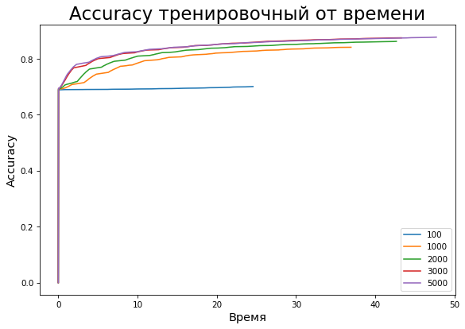

```python
plt.figure(figsize=(9,6), dpi=75)
for k in K:
    plt.plot(np.cumsum(to_drow[f'{k}']['time']), to_drow[f'{k}']['train_acc'], label=f'{k}')
plt.xlabel('Время', fontsize=14)
plt.ylabel('Accuracy', fontsize=14)
plt.title('Accuracy тренировочный от времени', fontsize=22)
plt.legend()
plt.show()
```

Попробуем увеличить min_df еще больше

```python
to_drow = {}
K = [100, 200, 300, 1000, 2000]
for k in K:
    vectorizer = TfidfVectorizer(min_df=k)
    X = vectorizer.fit_transform(corpus_train)
    X_test = vectorizer.transform(corpus_test)
    X = sp.sparse.hstack((X, np.ones(X.shape[0])[:, None]))
    X_test = sp.sparse.hstack((X_test, np.ones(X_test.shape[0])[:, None]))
    X = X.tocsr()
    X_test = X_test.tocsr()
    w_0 = np.zeros(X.shape[1])
    sgd = SGDClassifier('binary_logistic',
                    batch_size=10000,
                    step_alpha=0.1,
                    step_beta=0,
                    l2_coef=1e-6)
    history = sgd.fit(X,
                  y,
                  w_0,
                  True,
                  X_test=X_test,
                  y_test=y_test)
    to_drow[f'{k}'] = history
```

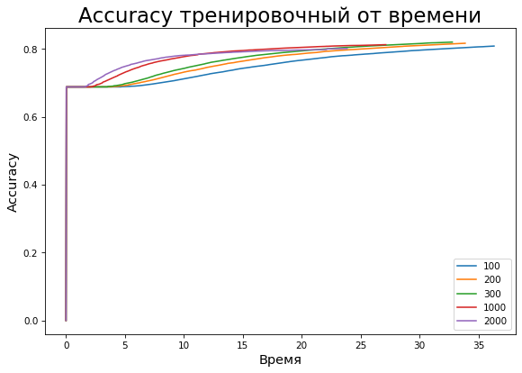

```python
plt.figure(figsize=(9,6), dpi=75)
for k in K:
    plt.plot(np.cumsum(to_drow[f'{k}']['time']), to_drow[f'{k}']['train_acc'], label=f'{k}')
plt.xlabel('Время', fontsize=14)
plt.ylabel('Accuracy', fontsize=14)
plt.title('Accuracy тренировочный от времени', fontsize=22)
plt.legend()
plt.show()
```

```python
print('Accuracy min_df=300:', max(to_drow['300']['train_acc']))
print('Accuracy min_df=1000:', max(to_drow['1000']['train_acc']))
```

```
Accuracy min_df=300: 0.8204798217475654
Accuracy min_df=1000: 0.8129117765697931
```

Получается использование tf-idf показывает лучший результат, если избавится от достаточно большого количества редких слов.

Теперь посмотрим что получилось на тестовой выборке.

```python
vectorizer = CountVectorizer(min_df=1)
X = vectorizer.fit_transform(corpus_train)
X = sp.sparse.hstack((X, np.ones(X.shape[0])[:, None]))
X = X.tocsr()
X_test = vectorizer.transform(corpus_test)
X_test = sp.sparse.hstack((X_test, np.ones(X_test.shape[0])[:, None]))
X_test = X_test.tocsr()
w_0 = np.zeros(X.shape[1])
sgd = SGDClassifier('binary_logistic',
                    batch_size=10000,
                    step_alpha=0.1,
                    step_beta=0,
                    l2_coef=1e-6)
sgd.fit(X, y, w_0)
```

```python
mask_true = sgd.predict(X_test) == y_test
```

Точность на тестовой выборке

```python
print('Accuracy top:', (mask_true).sum() / y_test.shape[0])
```

```
Accuracy top: 0.855000967305088
```

```python
pd.options.display.max_colwidth = 1000
```

Посмотрим на классы ошиобок:

```python
mask = df_test.loc[~mask_true]['is_toxic'] == True
```

```python
mask.sum() / len(mask)
```

```
0.6641094062708472
```

Большая часть ошибок когда классификатор говорит что комментарий не токсичен, хотя он таковым является.

Посмотрим на неправильно классифицированные:

```python
df_test.loc[~mask_true].iloc[0]
```

```
Unnamed: 0                                                                                                                                                                                                                                                                                                  …
comment_text    "::: Somebody will invariably try to add Religion?  Really??  You mean, the way people have invariably kept adding ""Religion"" to the Samuel Beckett infobox?  And why do you bother bringing up the long-dead completely non-existent ""Influences"" issue?  You're just flailing, making …
is_toxic                                                                                                                                                                                                                                                                                                    …
Name: 2, dtype: object
```

```python
df_test.loc[~mask_true].iloc[1]
```

```
Unnamed: 0                                                                                                               8
comment_text    == Arabs are committing genocide in Iraq, but no protests in Europe. == \n\n May Europe also burn in hell.
is_toxic                                                                                                              True
Name: 8, dtype: object
```

```python
df_test.loc[~mask_true].iloc[2]
```

```
Unnamed: 0                                                                                                                                                                                                                        12
comment_text    . \n\n           Jews are not a race because you can only get it from your mother. Your own mention of Ethiopian Jews not testing \n           as Jews proves it is not, as well as the fact that we accept converts
is_toxic                                                                                                                                                                                                                       False
Name: 12, dtype: object
```

В 1 и 3 случаях кажется что комментарий действительно токсичный, при этом он в изначальной выборке помечен как не токсичный, при этом все эти комментарии разжигают межнациональную рознь, возможно можно было бы завести отдельный классификатор для этих классов чтобы улучшить качество предсказаний.